# KNN Model

###### Read Data From File

```r
library(dplyr)
# Read the input data file.
load(file = "crash2.rda")
```

##### Analyse the data

```r
# Check the class of input data
print(class(crash2))
```

```
## [1] "data.frame"
```

```r
# Check Dimensions of input data
print(dim(crash2))
```

```
## [1] 20207    44
```

```r
# Check columns present in the data
print(colnames(crash2))
```

```
##  [1] "entryid"     "source"      "trandomised" "outcomeid"   "sex"
##  [6] "age"         "injurytime"  "injurytype"  "sbp"         "rr"
## [11] "cc"          "hr"          "gcseye"      "gcsmotor"    "gcsverbal"
## [16] "gcs"         "ddeath"      "cause"       "scauseother" "status"
## [21] "ddischarge"  "condition"   "ndaysicu"    "bheadinj"    "bneuro"
## [26] "bchest"      "babdomen"    "bpelvis"     "bpe"         "bdvt"
## [31] "bstroke"     "bbleed"      "bmi"         "bgi"         "bloading"
## [36] "bmaint"      "btransf"     "ncell"       "nplasma"     "nplatelets"
## [41] "ncryo"       "bvii"        "boxid"       "packnum"
```

```r
# write to csv so that data can be
# analysed manually
#write.csv(crash2, "data.csv")
```

##### After performing manula preliminary analysis of the data, the columns identified as irrelevant are decided to be dropped. Below is the explanation and description of the columns that are dropped.

##### Column: “entryid” -> Unique id to identify patient.

##### Column: “scauseother” -> Specifies cuase of death for category other.

##### Column: “ddeath” -> Date of death.

##### Column: “ddischarge” -> Date of discharge from the hospital.

##### Column: “source” -> Source of communication or entry form of patient.

##### Column: “trandomised” -> Date of Randomization

##### Column: “outcomeid” -> Unique Number From Outcome Database

##### Column: “boxid” -> treatment uniqe combination along with packnum

##### Column: “packnum” -> treatment uniqe combination along with boxid

##### Column: “ndaysicu” -> Ndays in ICU should not be considered as it may not be known at the time of admission.

##### Column: “status” -> Status specifies the current status of the patient. It acts like information leak.

##### Column: “cause” -> Specifies the cause of death for the patient. It acts like information leak.

```r
# Drop the columns specified above.
working.dataset <- subset(crash2, select = -c(entryid, scauseother, ddeath, ddischarge, source, trandomised, outcomeid, boxid, packnum, ndaysicu, status, cause))
# Check whether columns dropped successfully or not
print(dim(working.dataset))
```

```
## [1] 20207    32
```

```r
# Get the columns in dataset again
print(colnames(working.dataset))
```

```
##  [1] "sex"        "age"        "injurytime" "injurytype" "sbp"
##  [6] "rr"         "cc"         "hr"         "gcseye"     "gcsmotor"
## [11] "gcsverbal"  "gcs"        "condition"  "bheadinj"   "bneuro"
## [16] "bchest"     "babdomen"   "bpelvis"    "bpe"        "bdvt"
## [21] "bstroke"    "bbleed"     "bmi"        "bgi"        "bloading"
## [26] "bmaint"     "btransf"    "ncell"      "nplasma"    "nplatelets"
## [31] "ncryo"      "bvii"
```

##### Check the class of the columns in working data.

```r
for (col in colnames(working.dataset))
{
  cat(sprintf("\"%s\" \"%s\"\n", col, class(working.dataset[[col]])))
}
```

```
## "sex" "factor"
## "age" "integer"
## "injurytime" "numeric"
## "injurytype" "factor"
## "sbp" "integer"
## "rr" "integer"
## "cc" "integer"
## "hr" "integer"
## "gcseye" "integer"
## "gcsmotor" "integer"
## "gcsverbal" "integer"
## "gcs" "integer"
## "condition" "labelled"
##  "condition" "factor"
## "bheadinj" "integer"
## "bneuro" "integer"
## "bchest" "integer"
## "babdomen" "integer"
## "bpelvis" "integer"
## "bpe" "integer"
## "bdvt" "integer"
## "bstroke" "integer"
## "bbleed" "integer"
## "bmi" "integer"
## "bgi" "integer"
## "bloading" "integer"
## "bmaint" "integer"
## "btransf" "integer"
## "ncell" "numeric"
## "nplasma" "integer"
## "nplatelets" "integer"
## "ncryo" "integer"
## "bvii" "integer"
```

##### In the given dataset, the problem statement is to predict or classify “condition” column which signifies condition of the patient when discharged. In addition, classification must also be performed to understand whether the patient looses his life. There is a need to add another level in this column to specify whether the patient has lost the life. Below code is to try and add another level “dead” to signify that the patient has lost the life.

```r
# Add another level "dead" to the condition column
levels(working.dataset$condition) <- c(levels(working.dataset$condition), "dead")
# Apply newly added dead level to all NAs in the condition column
working.dataset$condition[-which(is.na(crash2$ddeath))] <- "dead"
# Check if level is applied correctly
any(is.na(working.dataset$condition))
```

```
## [1] TRUE
```

```r
head(working.dataset$condition)
```

```
## [1] dead           minor symptoms no symptoms    dead           no symptoms
## [6] dead
## 6 Levels: no symptoms ... dead
```

```r
#NAs are still present in condition
# Count the NAs present in condition
# gives 165, we can certainly neglect
# these 165 entries considering size of
# dataset. Also these are the patients
# moved to other hospitals, so the
# final condition of the patients
# is unknown.
print(length(working.dataset$condition[is.na(working.dataset$condition)]))
```

```
## [1] 165
```

```r
# check number of NAs present in status
# when condition NAs are removed
# 0 that is perfect.
temp.dataset <- working.dataset[-which(is.na(working.dataset$condition)), ]
print(length((temp.dataset$status[is.na(temp.dataset$status)])))
```

```
## [1] 0
```

##### Print all the columns in working data that are represented as factors. These columns need to be represented as numeric values so that can be used in the classification by applying scale. Once the factors are represented as numeric values, dataset will be easier to perform classification.

```r
for(col in colnames(working.dataset))
{
  if(is.factor(working.dataset[[col]]))
    print(col)
}
```

```
## [1] "sex"
## [1] "injurytype"
## [1] "condition"
```

##### Delete all the rows with NA in condition attribute, which is a class attribute for classification.

```r
# Prepare dataset without Condition NAs
working.dataset <- working.dataset[-which(is.na(working.dataset$condition)), ]
```

##### Check final working dataset

```r
dim(working.dataset)
```

```
## [1] 20042    32
```

#### Replace NAs with 0 For columns “ncell”, “nplasma”, “nplatelets” and “ncryo”

```r
working.dataset$ncell[is.na(working.dataset$ncell)] <- 0
working.dataset$nplasma[is.na(working.dataset$nplasma)] <- 0
working.dataset$nplatelets[is.na(working.dataset$nplatelets)] <- 0
working.dataset$ncryo[is.na(working.dataset$ncryo)] <- 0

dim(working.dataset)
```

```
## [1] 20042    32
```

```r
working.dataset <- working.dataset[complete.cases(working.dataset), ]
dim(working.dataset)
```

```
## [1] 18104    32
```

##### Categorizing condition into three classes

```r
working.dataset$condition_severity <- factor(case_when(
  working.dataset$condition  == "dead" ~ "Dead",
  working.dataset$condition  == "fully dependent, requiring attention day and night" ~ "Dependent",
  working.dataset$condition  == "dependent, but not requiring constant attention" ~ "Dependent",
  working.dataset$condition  == "some restriction in lifestyle but independent" ~ "Independent",
  working.dataset$condition  == "minor symptoms" ~ "Independent",
  working.dataset$condition  == "no symptoms" ~ "Independent",
  TRUE ~ "Unknown"
), levels = c("Dead", "Dependent", "Independent"))

working.dataset$condition <- working.dataset$condition_severity
working.dataset <- subset(working.dataset, select = -c(condition_severity))
colnames(working.dataset)
```

```
##  [1] "sex"        "age"        "injurytime" "injurytype" "sbp"
##  [6] "rr"         "cc"         "hr"         "gcseye"     "gcsmotor"
## [11] "gcsverbal"  "gcs"        "condition"  "bheadinj"   "bneuro"
## [16] "bchest"     "babdomen"   "bpelvis"    "bpe"        "bdvt"
## [21] "bstroke"    "bbleed"     "bmi"        "bgi"        "bloading"
## [26] "bmaint"     "btransf"    "ncell"      "nplasma"    "nplatelets"
## [31] "ncryo"      "bvii"
```

```r
levels(working.dataset$condition)
```

```
## [1] "Dead"        "Dependent"   "Independent"
```

##### Split Dataset into training, validation and test.

```r
# Import caret
library("caret")
# set seed
set.seed(108)

# Get Training DataSet
TrainingIndexes <- createDataPartition(y = working.dataset$condition, p = 0.6)

# Get Training Dataset
Training.Dataset <- working.dataset[TrainingIndexes[[1]], ]

# Dimension of training dataset
dim(Training.Dataset)
```

```
## [1] 10864    32
```

```r
# Test and Evaluation Dataset
TestAndValidationDataSet <- working.dataset[-TrainingIndexes[[1]], ]

# Dimensions for Test and Validation Dataset
dim(TestAndValidationDataSet)
```

```
## [1] 7240   32
```

```r
# Split TestAndValidationDataSet further in 50:50
# set seed
set.seed(108)
# Get Test DataSet
TestIndexes <- createDataPartition(y = TestAndValidationDataSet$condition, p = 0.5)

# Get Test DataSet
Test.Dataset <- TestAndValidationDataSet[TestIndexes[[1]], ]

# Get dimenstions of Test DataSet
dim(Test.Dataset)
```

```
## [1] 3621   32
```

```r
# Get Validation DataSet
Validatioin.Dataset <- TestAndValidationDataSet[-TestIndexes[[1]], ]

# Get dimensions of Validation DataSet
dim(Validatioin.Dataset)
```

```
## [1] 3619   32
```

```r
# Create rda files for all three dataset
save(Training.Dataset, file = "Training.Dataset.rda")
save(Test.Dataset, file = "Test.Dataset.rda")
save(Validatioin.Dataset, file = "Validatioin.Dataset.rda")
Validatioin.Dataset <- NULL
Test.Dataset <- NULL
Training.Dataset <- NULL
```

##### Validate files

```r
load(file = "Training.Dataset.rda")
load(file = "Test.Dataset.rda")
load(file = "Validatioin.Dataset.rda")
dim(Training.Dataset)
```

```
## [1] 10864    32
```

```r
dim(Test.Dataset)
```

```
## [1] 3621   32
```

```r
dim(Validatioin.Dataset)
```

```
## [1] 3619   32
```

```r
#feature selected by step forward method.

final_col <- c("age", "injurytime", "injurytype", "sbp", "rr", "cc", "gcseye", "gcsmotor", "gcs",
                         "bheadinj", "bchest", "babdomen", "bpelvis", "bpe", "bdvt", "bstroke", "bbleed", "bmi",
                        "bgi", "bmaint", "ncell", "nplasma", "nplatelets", "ncryo","condition")

K_TrainDataSet<-Training.Dataset[final_col]
K_ValidationDataSet <- Validatioin.Dataset[final_col]
```

#Converting categorical values into numeric value so can apply normalization

```r
#blunt=1 ,penetrating =2, blunt and penetrating =3

K_TrainDataSet$injurytype=as.numeric(K_TrainDataSet$injurytype)
K_ValidationDataSet$injurytype=as.numeric(K_ValidationDataSet$injurytype)
```

#normalization function

```r
#Normalization
normalize <- function(x) {
return ((x - min(x)) / (max(x) - min(x))) }
```

#Remove target class so can apply normalization

```r
normalize_TraindataSet <- subset(K_TrainDataSet, select = -c(condition))
normalize_ValidationdataSet <- subset(K_ValidationDataSet, select = -c(condition))

#normalize_date= K_NearDataSet[-c 'condition']
```

#Apply normazilation

```r
TrainNormalization<- normalize(normalize_TraindataSet)
ValidationNormalization<- normalize(normalize_ValidationdataSet)
```

#Final Data set combine with target class

```r
Final_TrainNormalizeDataSet<- cbind(TrainNormalization, condition=K_TrainDataSet$condition)
Final_ValidationNormalizeDataSet<- cbind(ValidationNormalization, condition=K_ValidationDataSet$condition)
```

#Extract the target labels so can pass parameter to KNN

```r
Target_train_labels <- K_TrainDataSet$condition
Target_validation_labels <-K_ValidationDataSet$condition
```

#creating K-nearst Neighbour Model

```r
 library(class)



 MY_KnnModel <- knn(TrainNormalization,ValidationNormalization,cl=Target_train_labels,k=9)
```

#finding optimal value of K using caret class funtion’Train’

```r
Optimal_K_Value <- train(TrainNormalization, Target_train_labels, method = "knn", preProcess = c("center","scale"))
```

```r
Optimal_K_Value
```

```
## k-Nearest Neighbors
##
## 10864 samples
##    24 predictor
##     3 classes: 'Dead', 'Dependent', 'Independent'
##
## Pre-processing: centered (24), scaled (24)
## Resampling: Bootstrapped (25 reps)
## Summary of sample sizes: 10864, 10864, 10864, 10864, 10864, 10864, ...
## Resampling results across tuning parameters:
##
##   k  Accuracy   Kappa
##   5  0.6585221  0.2874565
##   7  0.6722710  0.2995892
##   9  0.6834773  0.3112520
##
## Accuracy was used to select the optimal model using the largest value.
## The final value used for the model was k = 9.
```

#Plot the accuracy at different K values

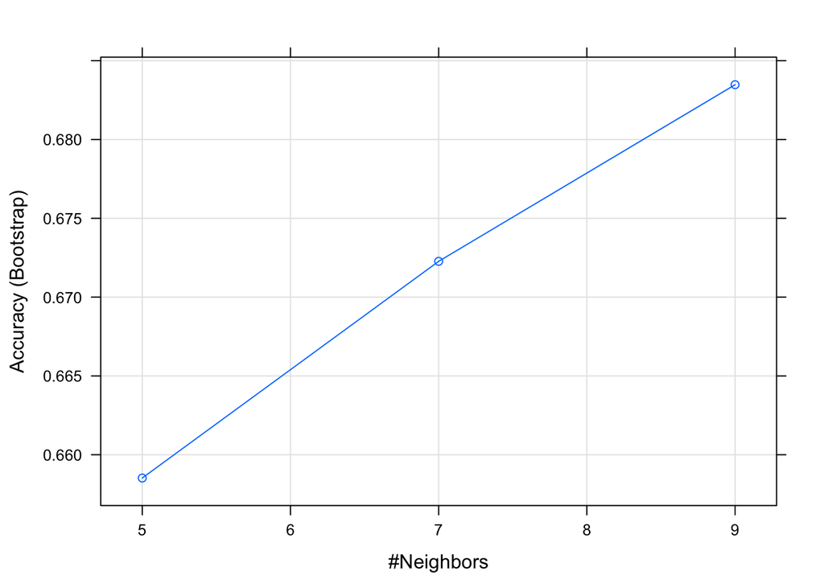

```r
plot(Optimal_K_Value)
```

#cross Table of the model

```r
#install.packages("gmodels")
library(gmodels)
CrossTable(x=Target_validation_labels,y=MY_KnnModel, prop.chisq = FALSE, prop.c = FALSE, prop.r = FALSE, prop.t = FALSE)
```

```
##
##
##    Cell Contents
## |-------------------------|
## |                       N |
## |-------------------------|
##
##
## Total Observations in Table:  3619
##
##
##                          | MY_KnnModel
## Target_validation_labels |        Dead |   Dependent | Independent |   Row Total |
## -------------------------|-------------|-------------|-------------|-------------|
##                     Dead |         170 |          80 |         285 |         535 |
## -------------------------|-------------|-------------|-------------|-------------|
##                Dependent |          77 |          69 |         576 |         722 |
## -------------------------|-------------|-------------|-------------|-------------|
##              Independent |          68 |          90 |        2204 |        2362 |
## -------------------------|-------------|-------------|-------------|-------------|
##             Column Total |         315 |         239 |        3065 |        3619 |
## -------------------------|-------------|-------------|-------------|-------------|
##
##
```

#Confusion Matric

```r
confusionMatrix(MY_KnnModel ,Target_validation_labels)
```

```
## Confusion Matrix and Statistics
##
##              Reference
## Prediction    Dead Dependent Independent
##   Dead         170        77          68
##   Dependent     80        69          90
##   Independent  285       576        2204
##
## Overall Statistics
##
##                Accuracy : 0.675
##                  95% CI : (0.6595, 0.6903)
##     No Information Rate : 0.6527
##     P-Value [Acc > NIR] : 0.002376
##
##                   Kappa : 0.2285
##
##  Mcnemar's Test P-Value : < 2.2e-16
##
## Statistics by Class:
##
##                      Class: Dead Class: Dependent Class: Independent
## Sensitivity              0.31776          0.09557             0.9331
## Specificity              0.95298          0.94132             0.3150
## Pos Pred Value           0.53968          0.28870             0.7191
## Neg Pred Value           0.88953          0.80680             0.7148
## Prevalence               0.14783          0.19950             0.6527
## Detection Rate           0.04697          0.01907             0.6090
## Detection Prevalence     0.08704          0.06604             0.8469
## Balanced Accuracy        0.63537          0.51844             0.6241
```